# 00 JupyterLab User Interface

## JypyterLab User Interface

- The JupyterLab starts with its **Launcher** tab open on its tabbed editor [1].
- Launcher lists shortcut icons for creating a new notebook with any of the currently **available kernels** [2].
- Alternatively, an existing notebook could be opened from the **File browser** available on the left sidebar [3].

[figure not shown]

- Launching a new notebook or loading an existing one opens the notebook on **a new tab** on its **tabbed editor** [1].
- Each notebook tab has its own **toolbar** with the most important actions [2].
- A simple notebook is displayed with its **Markdown cells** [3], **code cells** [4] and their **results** [5].
- On the left side of each cell is its execution number, or empty brackets, when the cell has not been successfully executed yet.
- The sidebar could be closed by clicking the currenly active tab [6].
- Most of the JupyterLab features are available for browsing and executing by Commands tab [7].

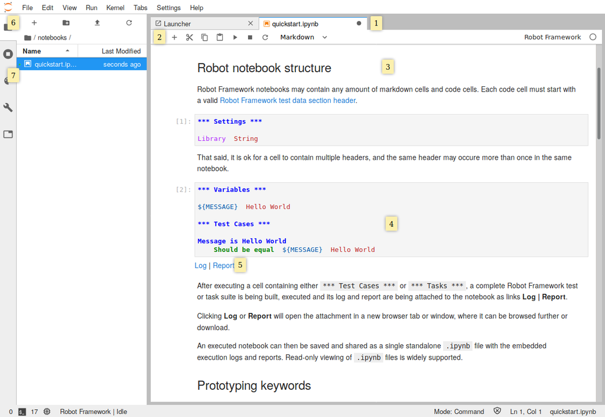

- **JupyterLab** includes **Contextual Help** tthat can display context aware code inspection information provided by the current kernel [1].

For example, **robotkernel** uses the Contextual Help for displaying context aware documentation – particularly documentation of the currently used keyword.

**Contextual Help** can be opened with `Ctrl + I`, from Commands-palette or from the context menu available on mouse click on a notebook. Contextual Help is opened as a separate tab, which can be dragged onto right or bottom side of the window – whichever suits best.

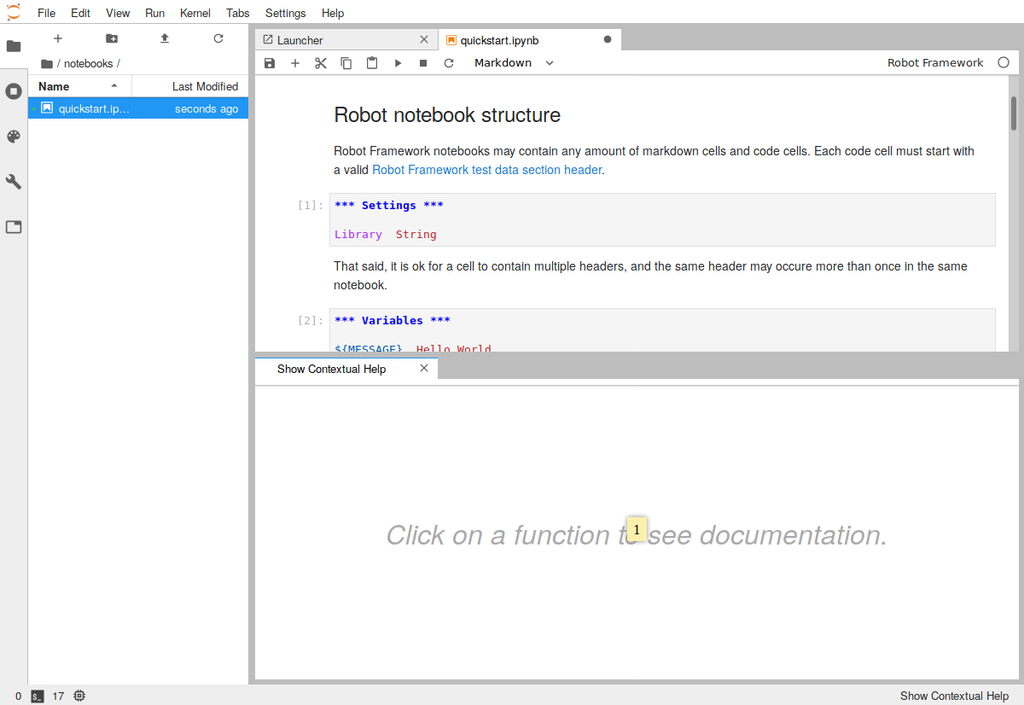